# Heart Disease Prediction

## Kayode Adeniyi¶

July 27th, 2020

In this project, I created visualizations of factors that increase risk of heart disease with Python matplotlib and seaborn. I then constructed logistic regression, random forest, k-nearest neighbor, and support vector machine algorithms to predict heart disease in patients with Python pandas, numpy and scikit-learn. In the last section, I evaluated and compared performances of models with confusion matrices and ROC curves. My personal goal for this proejct is to practice machine learning techniques and enrich my data visualization skills.

The dataset comes from the UCI Heart dataset on Kaggle.

You could access it through this link: https://www.kaggle.com/sonumj/heart-disease-dataset-from-uci

### Section 1: Data Exploration and Visualization

```python
import pandas as pd
import numpy as np
import seaborn as sns
import matplotlib.pyplot as plt
import matplotlib as mpl
#Making sure we have high resolution plots
mpl.rcParams['figure.dpi'] = 200

#Loading the UCI heart dataset
heart=pd.read_csv("heart.csv")
heart.head(10)
```

|  | age | sex | cp | trestbps | chol | fbs | restecg | thalach | exang | oldpeak | slope | ca | thal | target |
| --- | --- | --- | --- | --- | --- | --- | --- | --- | --- | --- | --- | --- | --- | --- |
| 0 | 63 | 1 | 3 | 145 | 233 | 1 | 0 | 150 | 0 | 2.3 | 0 | 0 | 1 | 1 |
| 1 | 37 | 1 | 2 | 130 | 250 | 0 | 1 | 187 | 0 | 3.5 | 0 | 0 | 2 | 1 |
| 2 | 41 | 0 | 1 | 130 | 204 | 0 | 0 | 172 | 0 | 1.4 | 2 | 0 | 2 | 1 |
| 3 | 56 | 1 | 1 | 120 | 236 | 0 | 1 | 178 | 0 | 0.8 | 2 | 0 | 2 | 1 |
| 4 | 57 | 0 | 0 | 120 | 354 | 0 | 1 | 163 | 1 | 0.6 | 2 | 0 | 2 | 1 |
| 5 | 57 | 1 | 0 | 140 | 192 | 0 | 1 | 148 | 0 | 0.4 | 1 | 0 | 1 | 1 |
| 6 | 56 | 0 | 1 | 140 | 294 | 0 | 0 | 153 | 0 | 1.3 | 1 | 0 | 2 | 1 |
| 7 | 44 | 1 | 1 | 120 | 263 | 0 | 1 | 173 | 0 | 0.0 | 2 | 0 | 3 | 1 |
| 8 | 52 | 1 | 2 | 172 | 199 | 1 | 1 | 162 | 0 | 0.5 | 2 | 0 | 3 | 1 |
| 9 | 57 | 1 | 2 | 150 | 168 | 0 | 1 | 174 | 0 | 1.6 | 2 | 0 | 2 | 1 |

#### Distribution of heart disease in the dataset

As the chart below presents, the number of patients with and without heart disease are relatively similar.

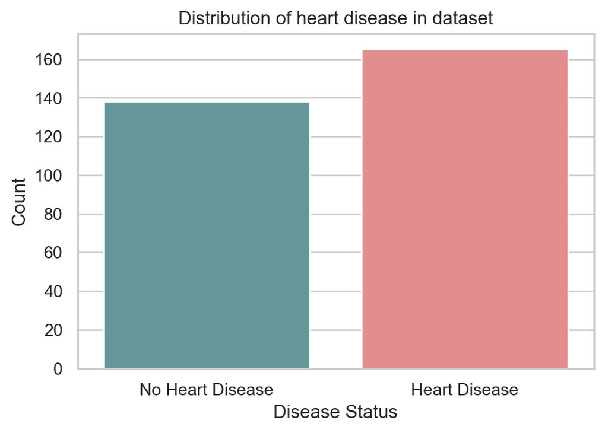

```python
sns.set(style="whitegrid")
sns.countplot(x=heart.target, data=heart,  palette= ("cadetblue","lightcoral"))
plt.title("Distribution of heart disease in dataset" )
plt.xlabel("Disease Status")
plt.xticks([0,1], labels=("No Heart Disease", "Heart Disease"))
plt.ylabel("Count")
plt.show()
```

#### Age Distribution of Patients

While many may assume that heart diseases are more frequent among older people, this dataset tells a different story. Age of patients without heart dieases has a higher mean and lower standard diviationthan that of patients with heart disease.

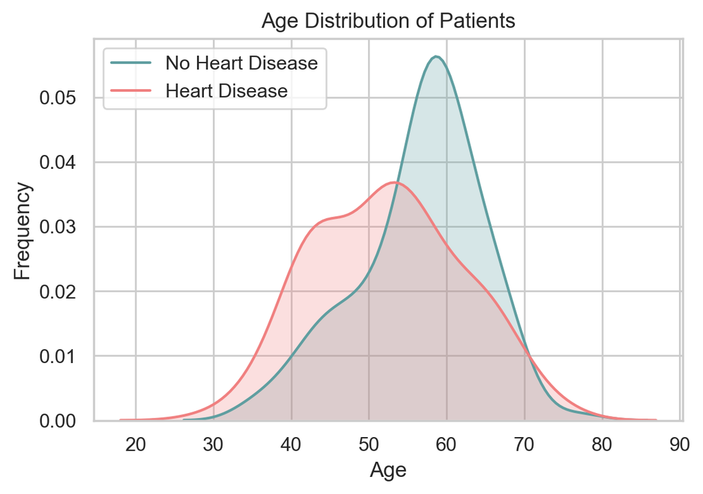

```python
sns.set(style="whitegrid")
sns.kdeplot(heart["age"][heart["target"]==0], shade=True, color="cadetblue")
sns.kdeplot(heart["age"][heart["target"]==1], shade=True, color="lightcoral")
plt.title('Age Distribution of Patients')
plt.legend(("No Heart Disease", "Heart Disease"))
plt.xlabel("Age")
plt.ylabel("Frequency")
plt.show()
```

#### Maximum Heart Rate Achieved Across Age, by Disease Status

Given the interesting discovery on age in the previous chart, I then explored how other variables differ by disease status across age. As the following chart shows, patients with heart diseases have overall higher maxium heart rate achieved than that of patients without heart diseases. Perhaps this variables is an important indicator for having heart disease.

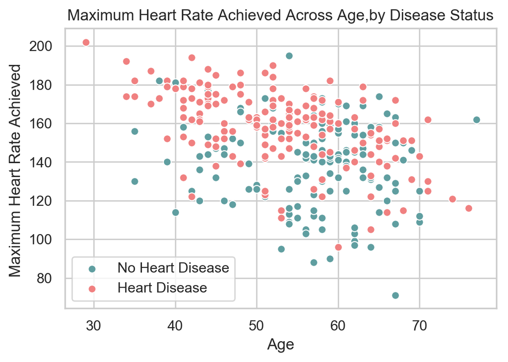

```python
sns.set(style="whitegrid")
sns.scatterplot(x="age", y="thalach", data=heart[heart["target"]==0], color="cadetblue")
sns.scatterplot(x="age", y="thalach", data=heart[heart["target"]==1],color="lightcoral")
plt.title("Maximum Heart Rate Achieved Across Age,by Disease Status")
plt.legend(loc="lower left",labels=("No Heart Disease", "Heart Disease"))
plt.xlabel("Age")
plt.ylabel("Maximum Heart Rate Achieved ")
plt.show()
```

#### Maximum Heart Rate Achieved Among Patients, by Disease Status

To further explore this "maximum heart rate achieved" variable, I then created the following boxplot, which reveals the same pattern as the previous chart.

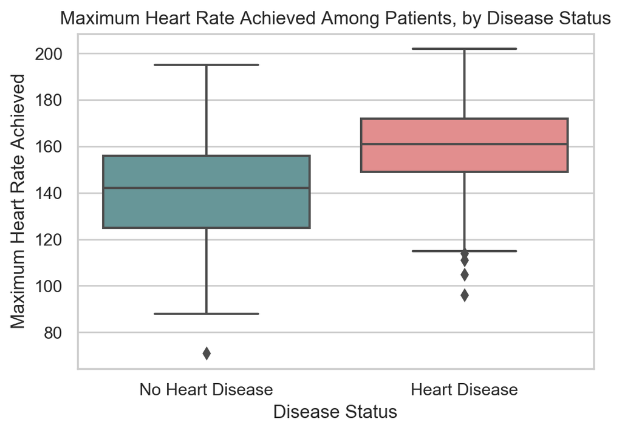

```python
sns.set(style="whitegrid")
sns.boxplot(x="target", y="thalach",data=heart,palette= ("cadetblue","lightcoral"))
plt.title("Maximum Heart Rate Achieved Among Patients, by Disease Status" )
plt.xlabel("Disease Status")
plt.xticks([0,1], labels=("No Heart Disease", "Heart Disease"))
plt.ylabel("Maximum Heart Rate Achieved")
plt.show()
```

#### Exercise Induced Angina Status, by Disease Status

Further, the majority of patients with heart diseases also did not have excercise induced angina. This could be another factor associated to heart disease risk.

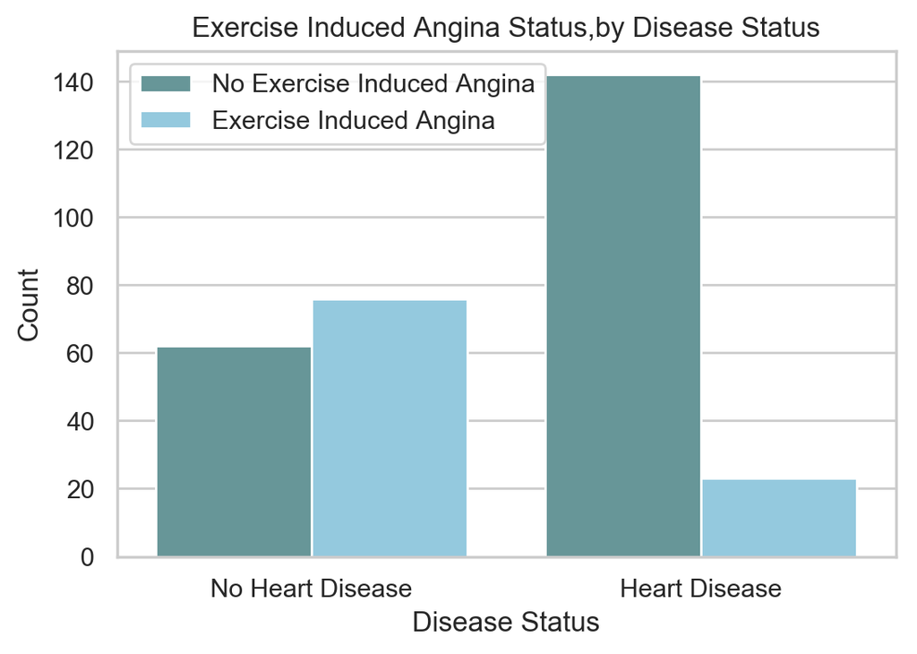

```python
sns.set(style="whitegrid")
sns.countplot(x=heart.target, data=heart, hue=heart.exang, palette= ("cadetblue","skyblue"))
plt.title("Exercise Induced Angina Status,by Disease Status" )
plt.xlabel("Disease Status")
plt.xticks([0,1], labels=("No Heart Disease", "Heart Disease"))
plt.legend(loc="upper left",labels=("No Exercise Induced Angina", "Exercise Induced Angina"))
plt.ylabel("Count")
plt.show()
```

#### ST depression induced by Exercise Among Patients, by Disease Status

Patients with heart diseases also had lower ST depression induced by exercise than that of patients without heart diseases.

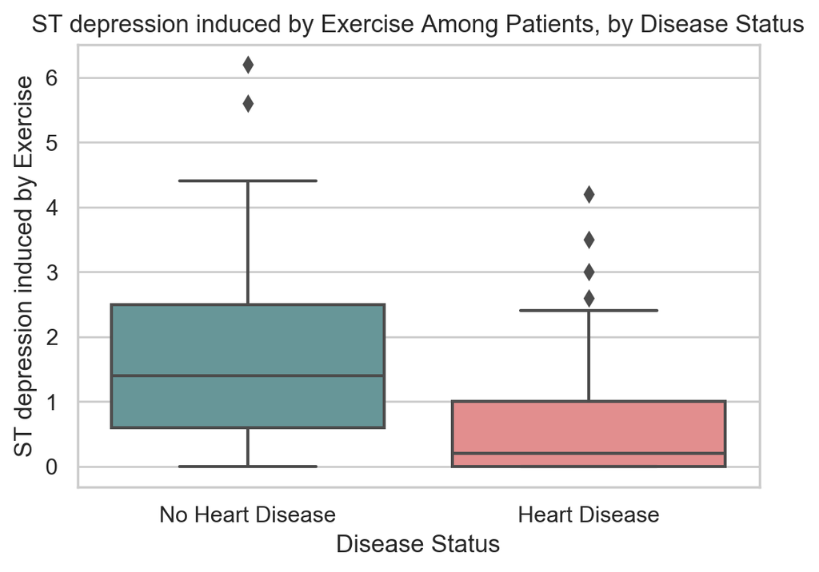

```python
sns.set(style="whitegrid")
sns.boxplot(x="target", y="oldpeak",data=heart,palette= ("cadetblue","lightcoral"))
plt.title("ST depression induced by Exercise Among Patients, by Disease Status" )
plt.xlabel("Disease Status")
plt.xticks([0,1], labels=("No Heart Disease", "Heart Disease"))
plt.ylabel("ST depression induced by Exercise")
plt.show()
```

#### Correlation Heatmap of all variables in the dataset

Since all variables in this dataset measures health of the cardiovascular system, I also plotted a correlation heatmap to ensure no variables are highly correlated with each other. As the following figure reveals, correlations between all variables are ralatively low.

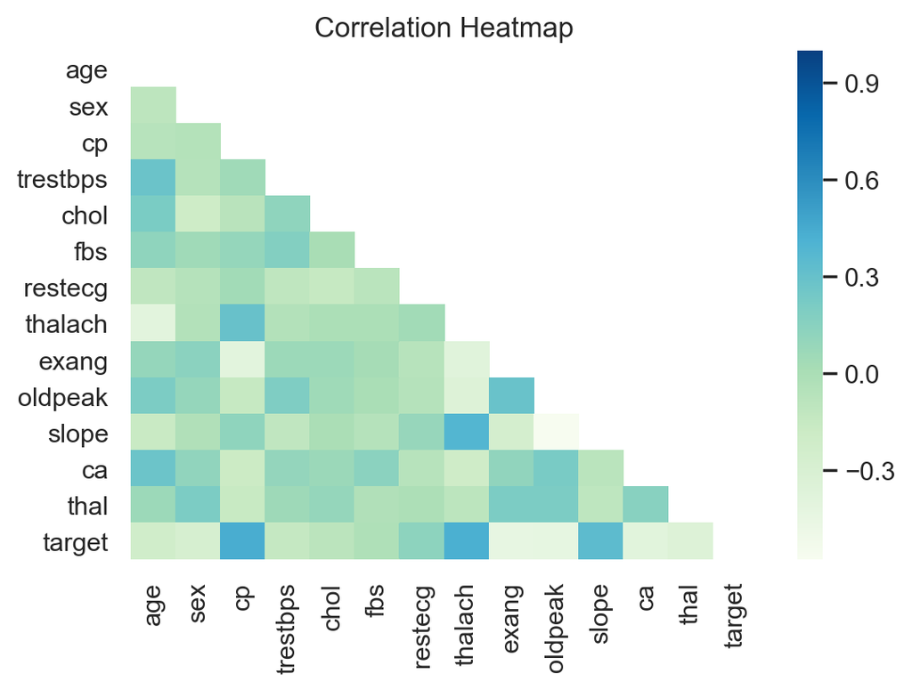

```python
#Create a mask to hide the repeated parts of the map
mask = np.zeros_like(heart.corr(), dtype=np.bool)
mask[np.triu_indices_from(mask)] = True
sns.heatmap(heart.corr(),xticklabels=heart.columns, yticklabels=heart.columns, mask=mask, cmap="GnBu")
plt.title("Correlation Heatmap")
plt.show()
```

### Section 2: Machine Learning Models

#### 2.1 Logistic Regression Model

```python
#Define x and y
X=heart[heart.columns[0:13]]
y=heart["target"]
```

```python
#Normalize data
X_norm = (X - np.min(X)) / (np.max(X) - np.min(X)).values
```

```python
#Split data into training and test sets: 80% will be training data and 20% will be test data
from sklearn.model_selection import train_test_split
X_train, X_test, y_train, y_test=train_test_split(X_norm,y, test_size=0.2, random_state=0)
```

```python
#Fit the logistic regression model
from sklearn.linear_model import LogisticRegression
lg_model=LogisticRegression(random_state = 10).fit(X_train, y_train)
```

```python
#Check accuracy of the logistic regression model
accuracy_scores=[]
accuracy= round(lg_model.score(X_test, y_test)*100,2)
#print("The accuracy of the logistic regression model is: %.2f percent" %accuracy)
accuracy_scores.append(accuracy)
```

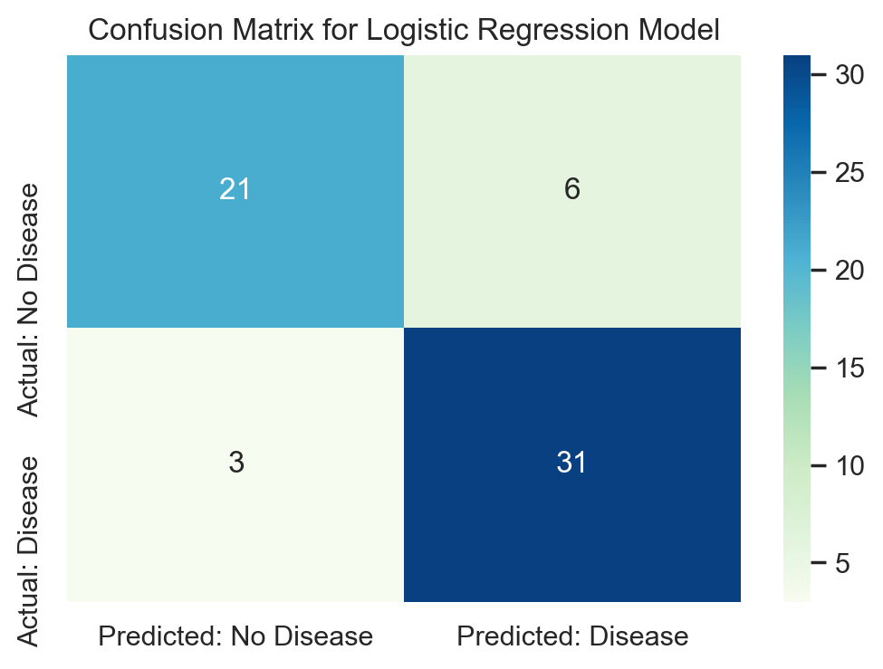

```python
#Construct the confusion matrix
from sklearn.metrics import confusion_matrix
y_predicted=lg_model.predict(X_test)
log_con= pd.DataFrame(confusion_matrix(y_test, y_predicted))
log_con.columns=["Predicted: No Disease", "Predicted: Disease"]
log_con.rename(index={0: "Actual: No Disease", 1: "Actual: Disease"},inplace=True)
sns.heatmap(log_con, annot=True, cmap="GnBu")
plt.title("Confusion Matrix for Logistic Regression Model")
plt.show()
```

```python
#Present in-depth report of the logistic regression model
from sklearn.metrics import classification_report
#Present more detailed report
#Precision is the positive perdictive value of the model
#Recall is the sensitivity of the test
print(classification_report(y_test, y_predicted))
##print("85% of patients that the model predicted to have heart disease actually had heart disease. 85% of paitents who actually had heart disease received correct prediction from the model.")
```

```
              precision    recall  f1-score   support

           0       0.88      0.78      0.82        27
           1       0.84      0.91      0.87        34

   micro avg       0.85      0.85      0.85        61
   macro avg       0.86      0.84      0.85        61
weighted avg       0.85      0.85      0.85        61
```

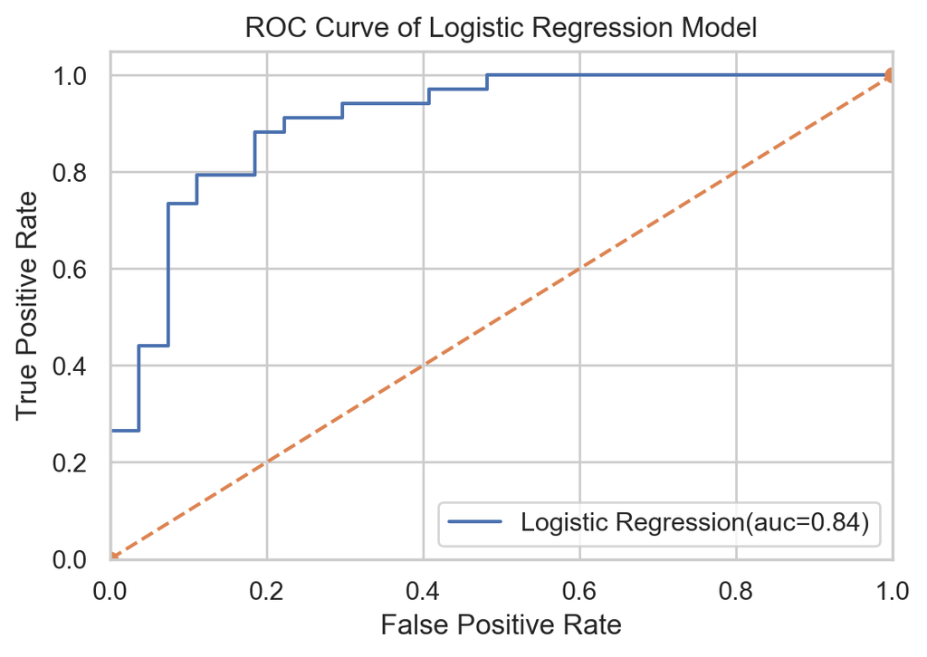

```python
#Construct the ROC curve for the Logistic Regression Model
from sklearn.metrics import roc_auc_score
from sklearn.metrics import roc_curve
import matplotlib.pyplot as plt

auc=roc_auc_score(y_test, y_predicted)
y_prob=lg_model.predict_proba(X_test)[:,1]

fpr, tpr, ther=roc_curve(y_test, y_prob)
plt.plot(fpr, tpr, label="Logistic Regression(auc=%0.2f)"%auc)
plt.plot([0, 1], [0, 1], "o--")
plt.xlim([0.0, 1.0])
plt.ylim([0.0, 1.05])
plt.xlabel('False Positive Rate')
plt.ylabel('True Positive Rate')
plt.title("ROC Curve of Logistic Regression Model")
plt.legend(loc="lower right")
plt.show()
```

#### 2.2 Random Forest

```python
#Fit the Random Forest Model
from sklearn.ensemble import RandomForestClassifier
rf=RandomForestClassifier(n_estimators = 1000, random_state = 10, max_depth=10)
rf_model=rf.fit(X_train, y_train)
rf_accuracy= round(rf_model.score(X_test, y_test)*100,2)
#print("The accuracy of the random forest model is: %.2f percent" %rf_accuracy)
accuracy_scores.append(rf_accuracy)
```

[output not shown]

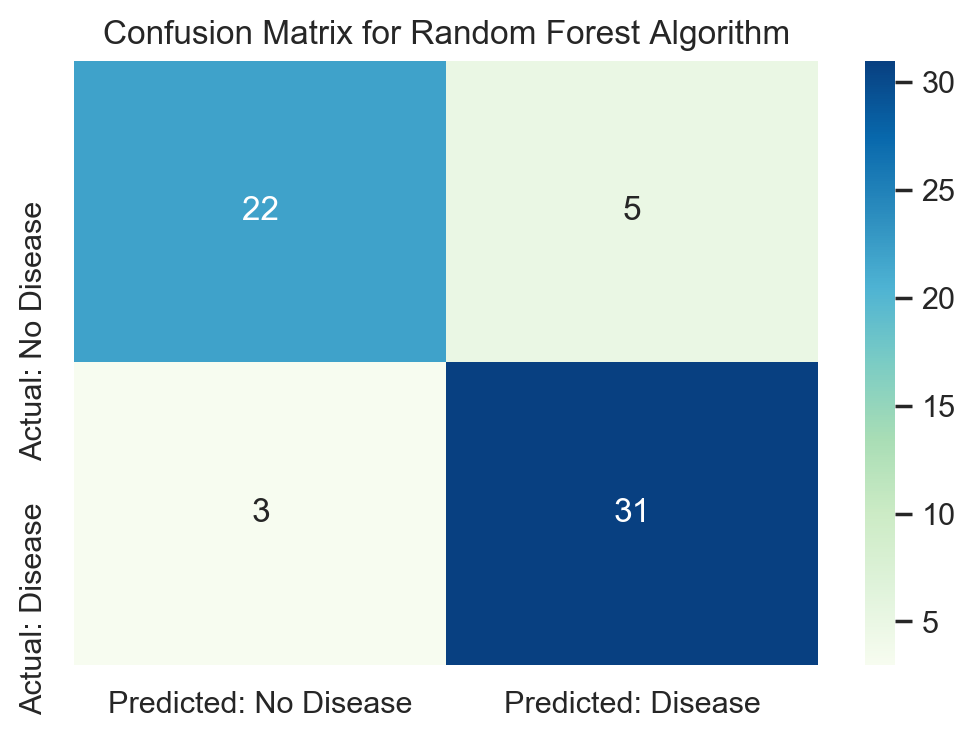

```python
#Construct the confusion matrix
rf_y_predict=rf_model.predict(X_test)
rf_con= pd.DataFrame(confusion_matrix(y_test, rf_y_predict))
rf_con.columns=["Predicted: No Disease", "Predicted: Disease"]
rf_con.rename(index={0: "Actual: No Disease", 1: "Actual: Disease"},inplace=True)
sns.heatmap(rf_con, annot=True, cmap="GnBu")
plt.title("Confusion Matrix for Random Forest Algorithm")
plt.show()
```

```python
# Present in-depth report of random forest algorithm
print(classification_report(y_test, rf_y_predict))
#print("87% of patients that the model predicted to have heart disease actually had heart disease. 87% of paitents who actually had heart disease received correct prediction from the model.")
```

[output not shown]

```
<function matplotlib.pyplot.show(*args, **kw)>
```

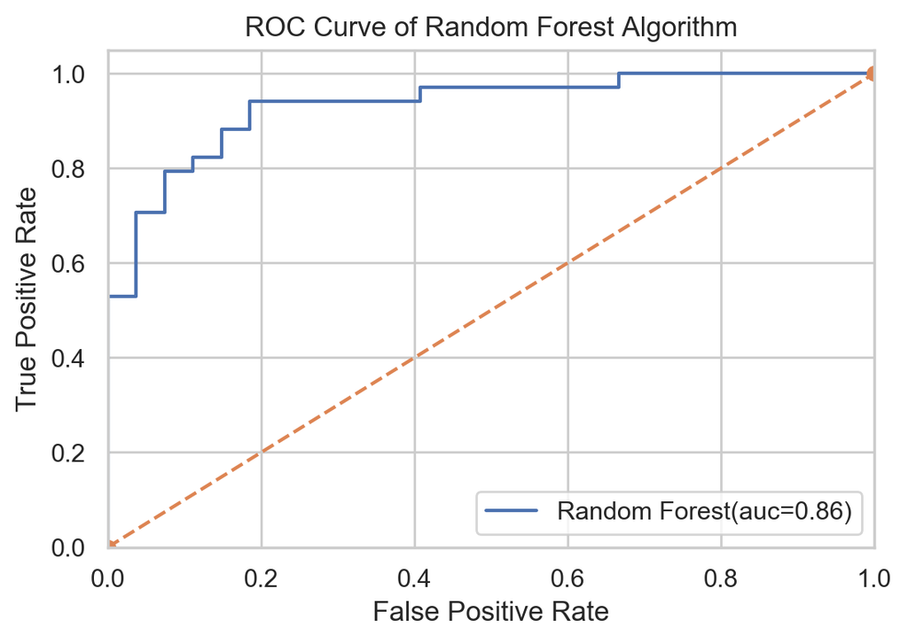

```python
#Construct the ROC curve for the Random Forest Algorithm
rf_auc=roc_auc_score(y_test, rf_y_predict)
rf_y_prob=rf_model.predict_proba(X_test)[:,1]
rf_fpr, rf_tpr, rf_ther=roc_curve(y_test, rf_y_prob)
plt.plot(rf_fpr, rf_tpr, label="Random Forest(auc=%0.2f)"%rf_auc)
plt.plot([0, 1], [0, 1], "o--")
plt.xlim([0.0, 1.0])
plt.ylim([0.0, 1.05])
plt.xlabel('False Positive Rate')
plt.ylabel('True Positive Rate')
plt.title("ROC Curve of Random Forest Algorithm")
plt.legend(loc="lower right")
plt.show
```

#### 2.3 K Nearest Neighbor

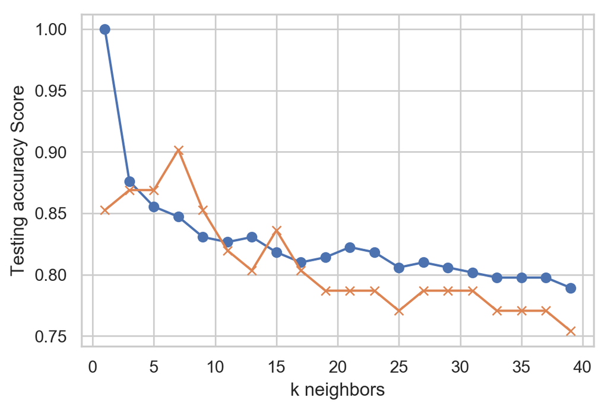

```python
from sklearn.neighbors import KNeighborsClassifier

#find the best k value by plotting out the accuracy scores
train_scores=[]
test_scores=[]
for k in range (1,40,2):
    knn = KNeighborsClassifier(n_neighbors=k)
    knn.fit(X_train, y_train)
    train_score=knn.score(X_train, y_train)
    test_score=knn.score(X_test, y_test)
    train_scores.append(train_score)
    test_scores.append(test_score)

plt.plot(range(1, 40, 2), train_scores, marker='o')
plt.plot(range(1, 40, 2), test_scores, marker="x")
plt.xlabel("k neighbors")
plt.ylabel("Testing accuracy Score")
plt.show()
```

```python
#From the chart above, k=7 seems to yield the best result
knn = KNeighborsClassifier(n_neighbors=7)
knn_model= knn.fit(X_train, y_train)
knn_accuracy= knn.score(X_test, y_test)*100
#print("The accuracy of the KNN model is: %.2f percent" %knn_accuracy)
accuracy_scores.append(knn_accuracy)
```

[output not shown]

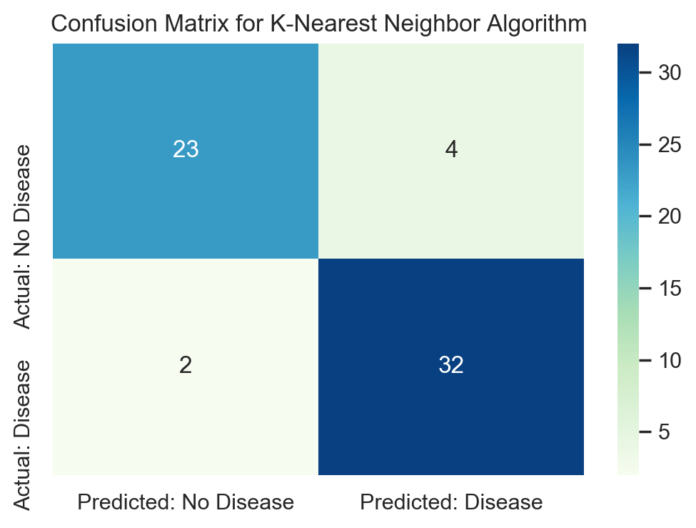

```python
#Construct the confusion matrix
knn_y_predict=knn_model.predict(X_test)
knn_con= pd.DataFrame(confusion_matrix(y_test, knn_y_predict))
knn_con.columns=["Predicted: No Disease", "Predicted: Disease"]
knn_con.rename(index={0: "Actual: No Disease", 1: "Actual: Disease"},inplace=True)
sns.heatmap(knn_con, annot=True, cmap="GnBu")
plt.title("Confusion Matrix for K-Nearest Neighbor Algorithm")
plt.show()
```

```python
# Present in-depth report of random forest algorithm
print(classification_report(y_test, knn_y_predict))
#print("90% of patients that the model predicted to have heart disease actually had heart disease. 90% of paitents who actually had heart disease received correct prediction from the model.")
```

[output not shown]

```
<function matplotlib.pyplot.show(*args, **kw)>
```

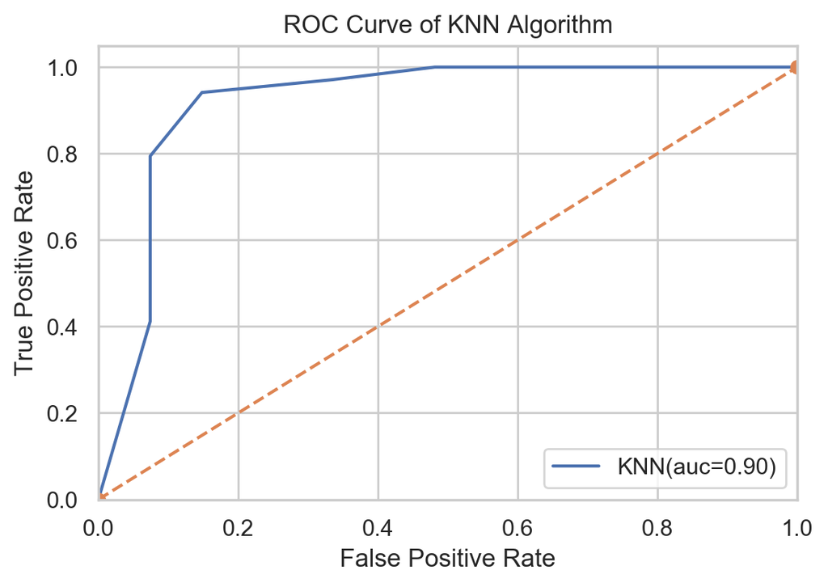

```python
#Construct the ROC curve for the KNN Algorithm
knn_auc=roc_auc_score(y_test, knn_y_predict)
knn_y_prob=knn_model.predict_proba(X_test)[:,1]
knn_fpr, knn_tpr, knn_ther=roc_curve(y_test, knn_y_prob)
plt.plot(knn_fpr, knn_tpr, label="KNN(auc=%0.2f)"%knn_auc)
plt.plot([0, 1], [0, 1], "o--")
plt.xlim([0.0, 1.0])
plt.ylim([0.0, 1.05])
plt.xlabel('False Positive Rate')
plt.ylabel('True Positive Rate')
plt.title("ROC Curve of KNN Algorithm")
plt.legend(loc="lower right")
plt.show
```